# PC3_2_InformeFinal

Jean Carlo Briceño Enriquez

2022-06-29

```r
library(tinytex)
library(Rmisc)
library (stargazer)
```

```
##  Hlavac, Marek (2022). stargazer: Well-Formatted Regression and Summary Statistics Tables.
```

```
##  R package version 5.2.3. https://CRAN.R-project.org/package=stargazer
```

```r
library(moments)
library(DescTools)
library(BBmisc)
library(cluster)
library(factoextra)
library(tidyverse)
library(dplyr)
library(stringr)
library(rio)
library(htmltab)
library(rvest)
library(stringr)
library(readr)
library(sp)
library(rgdal)
```

```r
library(ggplot2)
library(tidyverse)
library(sf)
```

**REPOSITORIO GITHUB: https://github.com/jean27272727/PC_3_EST2-.git** #Parte II: Elaboración del reporte

```r
Reporte_Final=import("https://github.com/jean27272727/PC_3_EST2-/blob/6436f292557f9ec63486cf65985a0bc3345a157d/Reporte.csv?raw=true", encoding="UTF-8", stringsAsFactors = F)
# eliminamos fila del año

Reporte_Final= Reporte_Final[,-2]
#Convertimos a numericas
Reporte_Final$`Emision Oxido Nitroso`= as.numeric(Reporte_Final$`Emision Oxido Nitroso`)
Reporte_Final$`Emicion Metano`= as.numeric(Reporte_Final$`Emicion Metano`)
str(Reporte_Final)
```

```
## 'data.frame':    142 obs. of  5 variables:
##  $ Pais                 : chr  "Albania" "Alemania" "Andorra" "Angola" ...
##  $ Emicion Co2          : int  1 1 1 1 1 1 1 1 1 1 ...
##  $ Emicion Metano       : num  3210 54780 50 37450 200 ...
##  $ Emision Oxido Nitroso: num  1210 34580 0 18490 20 ...
##  $ IDH_2019             : num  0.795 0.947 0.868 0.581 0.778 0.854 0.748 0.845 0.776 0.944 ...
```

## Introducccion

El presente trabajo pretende informar descriptivamente sobre un conjunto de indicadores: Emision de CO2, Emision de metano, Emision de oxido nitroso(del año 2017) y el IDH (del año 2019). Con el objetivo de Describir la situacion de España- en conjunto con los indicadores propuesto- con el resto del mundo. En este sentido, se procede a explicar los indicadores. En primer lugar, la Emision de CO2, se miden a partir de los derivados de la quema de combustible fósil y la fabricacion de cemento. En segundo lugar, las emiciones de metano, se miden a partir de los derivados de actividades humanas como la agricultura y de la produccion industrial de metano; ademas, se calcula en relacion a kt quivalenten al C02. En tercer lugar, las emisiones de oxido nitroso, de miden a partir de las emisiones de la quema de biomasa agricola, actividades industriales y manejo de ganado; ademas, se calcula a partir de toneladas métricas de Co2 equivalente . Por ultimo, el IDH se calcula como una media geométrica de medias geométricas para cada dimensión por separado. El IDH-D da cuenta de las desigualdades en las dimensiones del IDH ajustando el valor promedio de cada dimensión según su nivel de desigualdad.

## Tabla

```r
# creacion de la tabla del promedio de las tres variables y el IDH

colMeans(Reporte_Final[,c(3:5)])
```

```
##        Emicion Metano Emision Oxido Nitroso              IDH_2019
##          4.418746e+04          1.828324e+04          7.371127e-01
```

```r
#Valor de los indicadores para su país asignado
Reporte_Final[43,]
```

```
##      Pais Emicion Co2 Emicion Metano Emision Oxido Nitroso IDH_2019
## 43 España           1          39600                 20140    0.904
```

Para la creacion de la tabla es necesario primero la creacion de un nuevo valor “Caso_unico” que será de España, por tanto primero se procede a graficar para que despues se pueda crear la tabla.

##Gráficos

#a. La relación entre el IDH y uno de los indicadores elegidos del Banco Mundial

[figure not shown]

```r
Reporte_Final= mutate(Reporte_Final, Caso_unico= ifelse(Pais== "España", 1,0))
Reporte_Final$Caso_unico= factor(Reporte_Final$Caso_unico)

p=ggplot(Reporte_Final, aes(x=IDH_2019, y=`Emision Oxido Nitroso`)) + geom_point() +
geom_point(size=1.3, shape=23) +
geom_text(label=Reporte_Final$Pais, vjust=-0.5, hjust = 1,color="black", size=3) +
labs(title = "Indice de Desarrollo Humano en relacion al nivel de emicion de Co2",
subtitle = "2019,2017",
x = "Indice de Desarrollo Humano",
y = "Nivel de emicion de Co2")
p
```

Por el grafico se puede comprobar que no existe una relacion en la mayoria de paises, entre el Indice de Desarrollo humano del 2019 y la emision de oxido nitroso del año 2017. En tanto, se puede decir que India, China, Brasil, Indonesia y Estados Unidos pueden presentar una relacion directa. Ademas, en el caso especifico del país brindado para el analisis: España, se puede decir que no presenta ningun tipo de relacion entre la emision de oxido nitroso y el IDH.

# Retomando el punto anterior de la tabla y el grafico, una vez creado el valor : España se procede a realizar la tabla

```r
Tabla_final= as.data.frame(Reporte_Final %>%
  group_by(Caso_unico) %>%
  summarize(Mean_Emision_Metano= mean(`Emicion Metano`, na.rm= TRUE), Mean_Emision_Dioxido_Nitroso= mean(`Emision Oxido Nitroso`, na.rm= TRUE), Mean_IDH= mean( IDH_2019, na.rm= TRUE)))
```

```r
Tabla_final$Caso_unico = factor(Tabla_final$Caso_unico, levels = c(0:1), labels = c("Mundo", "España"))
Tabla_final
```

```
##   Caso_unico Mean_Emision_Metano Mean_Emision_Dioxido_Nitroso  Mean_IDH
## 1      Mundo               44220                     18270.07 0.7359291
## 2     España               39600                     20140.00 0.9040000
```

Segun la tabla mostrada, en promedio, en el mundo la emision de metano es de 44220 KT, el de dioxido nitroso es de 18270.07 kt y, mientras, el indice de desarrolllo humano es de 0,736. Ademas, el país seleccionado: España, presenta una emicion de metano de 39600 kt, que es menor al promedio del mundo. En tanto la emision de oxido nitroso supera al promedio mundial: 20140.00 kt ademas del IDH: 0,904.

#b. La distribución de países según la variable ordinal: Emicion de c02, en base a un mapa.

```r
mundo_map <- st_read("Paises_Mundo.shp")
```

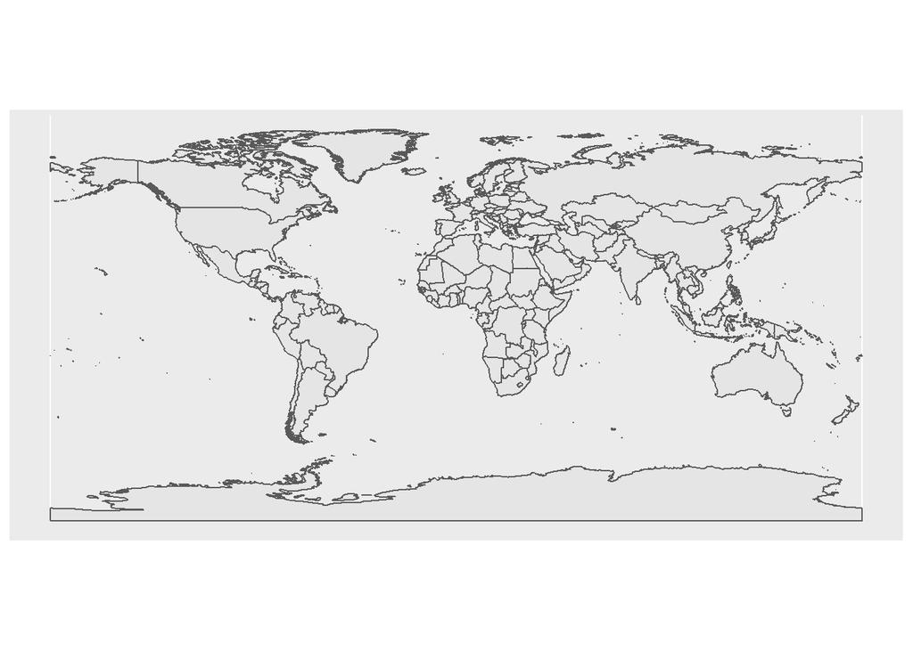

```r
mundo_map %>%
  ggplot() + # Crea un objeto ggplot a partir del objeto mex_map
  geom_sf() # agrega una capa con el mapa
```

```r
mundo_map
```

```
## Simple feature collection with 252 features and 1 field
## Geometry type: MULTIPOLYGON
## Dimension:     XY
## Bounding box:  xmin: -180 ymin: -90 xmax: 180 ymax: 83.6236
## Geodetic CRS:  WGS 84
## First 10 features:
##                      PAÍS                       geometry
## 1    Aruba (Paises Bajos) MULTIPOLYGON (((-69.88223 1...
## 2       Antigua y Barbuda MULTIPOLYGON (((-61.73889 1...
## 3              Afganistán MULTIPOLYGON (((61.27656 35...
## 4                 Argelia MULTIPOLYGON (((-5.152135 3...
## 5              Azerbaiyán MULTIPOLYGON (((46.54037 38...
## 6                 Albania MULTIPOLYGON (((20.79192 40...
## 7                 Armenia MULTIPOLYGON (((46.54037 38...
## 8                 Andorra MULTIPOLYGON (((1.445833 42...
## 9                  Angola MULTIPOLYGON (((13.09139 -4...
## 10 Samoa Americana (EEUU) MULTIPOLYGON (((-170.7439 -...
```

```r
Reporte_Final
```

[output not shown]

[output cut: 271 more lines]

```r
#se procede a crear una nueva tabla solo con CO2 para fines de la creacion del mapa
Casos_CO2 <- Reporte_Final %>% select(Pais, `Emicion Co2`) %>% group_by(Pais)

Casos_CO2
```

```
## # A tibble: 142 x 2
## # Groups:   Pais [142]
##    Pais              `Emicion Co2`
##    <chr>                     <int>
##  1 Albania                       1
##  2 Alemania                      1
##  3 Andorra                       1
##  4 Angola                        1
##  5 Antigua y Barbuda             1
##  6 Arabia Saudita                1
##  7 Argelia                       1
##  8 Argentina                     1
##  9 Armenia                       1
## 10 Australia                     1
## # ... with 132 more rows
```

```r
mundo_map_co2 <- mundo_map %>%
  # unir tablas
  left_join(Casos_CO2,
            # indicar explícitamente las columnas índice,
            # necesario cuando no tienen el mismo nombre
            by = c("PAÍS" = "Pais"))
```

```r
mundo_map_co2
```

```
## Simple feature collection with 252 features and 2 fields
## Geometry type: MULTIPOLYGON
## Dimension:     XY
## Bounding box:  xmin: -180 ymin: -90 xmax: 180 ymax: 83.6236
## Geodetic CRS:  WGS 84
## First 10 features:
##                      PAÍS Emicion Co2                       geometry
## 1    Aruba (Paises Bajos)          NA MULTIPOLYGON (((-69.88223 1...
## 2       Antigua y Barbuda           1 MULTIPOLYGON (((-61.73889 1...
## 3              Afganistán          NA MULTIPOLYGON (((61.27656 35...
## 4                 Argelia           1 MULTIPOLYGON (((-5.152135 3...
## 5              Azerbaiyán           1 MULTIPOLYGON (((46.54037 38...
## 6                 Albania           1 MULTIPOLYGON (((20.79192 40...
## 7                 Armenia           1 MULTIPOLYGON (((46.54037 38...
## 8                 Andorra           1 MULTIPOLYGON (((1.445833 42...
## 9                  Angola           1 MULTIPOLYGON (((13.09139 -4...
## 10 Samoa Americana (EEUU)          NA MULTIPOLYGON (((-170.7439 -...
```

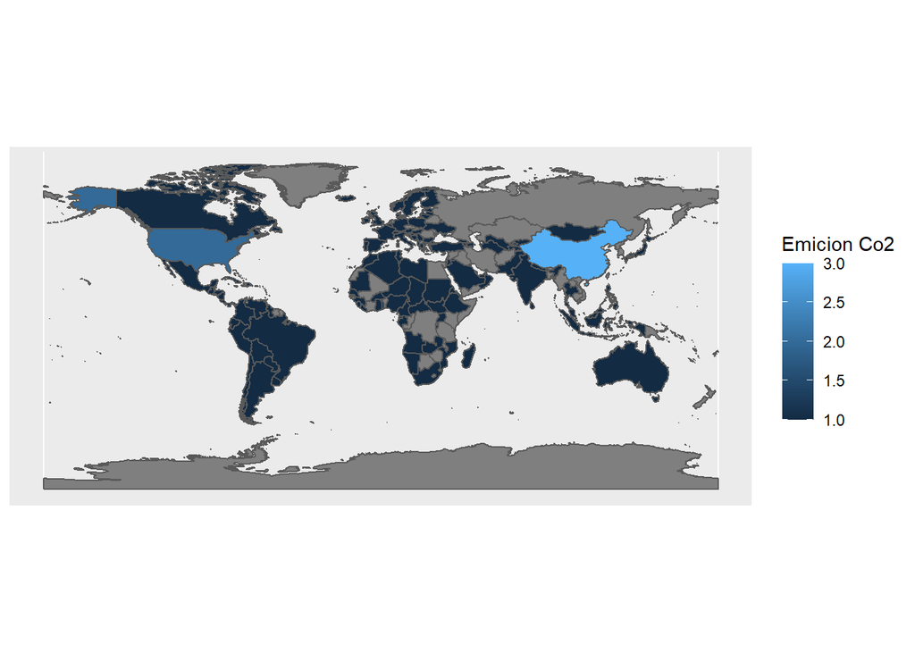

```r
#Primer mapa sin modificar (el sucio)
mundo_map_co2 %>%
  # usamos el aesthetic fill para indicar la columna de casos
  ggplot(aes(fill = `Emicion Co2`)) +
  geom_sf()
```

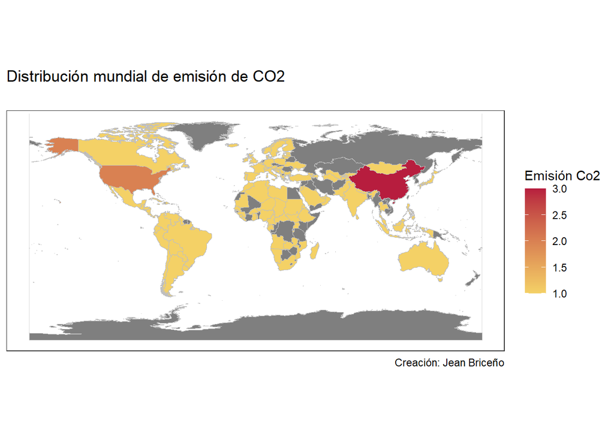

```r
#mapa final (la limpia)
mundo_map_co2 %>%
  # usamos el aesthetic fill para indicar la columna de casos
  ggplot(aes(fill = `Emicion Co2`)) +
  # cambia el color y el grosor de las líneas
  geom_sf(colour = "grey75", size = 0.07) +
  # agrega títulos
  labs(title = "Distribución mundial de emisión de CO2",
       subtitle = "",
       caption = "Creación: Jean Briceño") +
  # cambia el color de relleno y el título de la leyenda
  scale_fill_gradient("Emisión Co2", high = "#B71D3E", low = "#F4D166") +
  # retirar el fondo gris
  theme_bw()
```

##Categorias en Kilotones para el caso de emision de CO2 para el gráfico b Escala de 0-1 (-3.33e+04,3.71e+06] = 140 Escala de 1-2(3.71e+06,7.41e+06) = 1 Escala de 2-3 (7.41e+06,1.11e+07] = 1

Segun el gráfico: La mayoria de paises no sepera la escala 1. En tanto, solo dos superan dicha escala, China presenta una escala 3 y Estados Unidos presenta una escala 2. Mientras que el pais brindado por el presenta trabajo: España, presenta una escala 1.

# c.La densidad de emicion de metano elegidos del Banco Mundial.

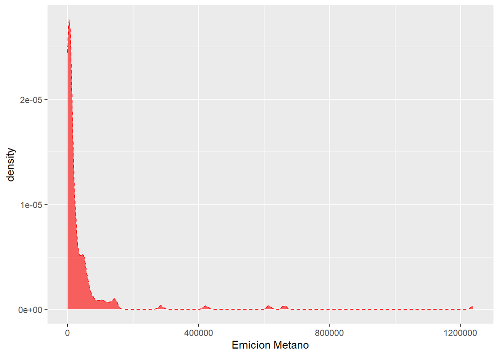

```r
ggplot(Reporte_Final, aes(x=`Emicion Metano`, fill=`Emision Metano`)) + theme(legend.position="bottom") +
geom_density(alpha=0.6, color="red", fill="red", linetype = "dashed")
```

# d. gráfico libre

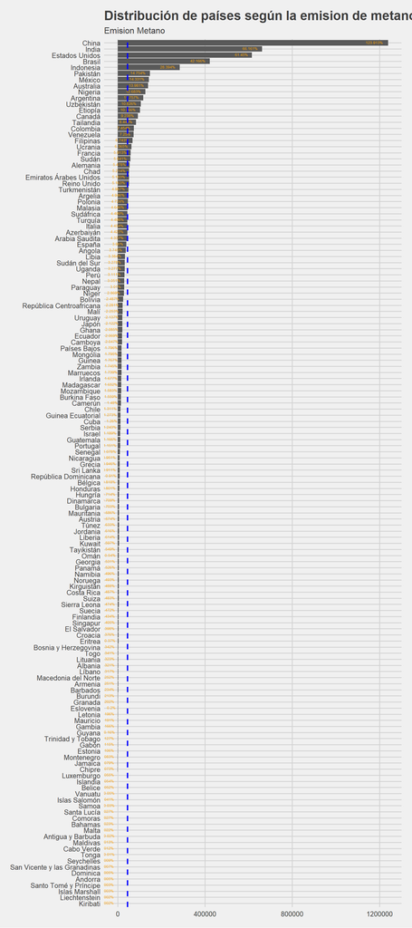

```r
library(ggthemes)
ggplot(Reporte_Final, aes(x=reorder(Pais,`Emicion Metano`), y=`Emicion Metano`)) +
geom_bar(stat = "identity") + coord_flip()+
labs(title = "Distribución de países según la emision de metano ",
subtitle = "Emision Metano",
x = " ",
y = "Escala 0 - 1200000") +


  geom_text(aes(label=paste0(round(`Emicion Metano`,4)/10000,"%")), vjust=0.3, hjust = 1.3, color="orange", size=1.9) +

    geom_hline(yintercept = mean(Reporte_Final$`Emicion Metano`) ,linetype="dashed", color="blue",size=1) +

  scale_color_fivethirtyeight() +

  theme_fivethirtyeight()
```

Según el grafico:

Por una parte, China supera el porcentaje maximo del mundo en emiciones de metano con un 124% (superior a 1200000 kt) aproximadamente y Kiribati se aproxima al minimo con 0,02%. Por otra parte, España emite un 4% de metano que es menos que el promedio mundial: 44220.

## Reporte de conclusiones

Segun los analisis y graficos presentados (del año 2017) se concluye lo siguiente, en primer lugar (según el gráfico de dispercion de puntos), que España, no presenta ningun tipo de relacion (directa o inversa) entre la emision de oxido nitroso y el IDH, por lo cual no es necesario basar un analisis y/o trabajo en conjunto de ambas varaibles para una posible disminucion o aumento de algunas de ellas. En segundo lugar (segun la tabla_final), España presenta una emision de metano de 39600 kt en el año 2017, que es menor al promedio del mundo; por lo cual, España, estaria contaminando menos que los otros paises que estan en el promedio o superan el promedio. En este sentido, la situacion del pais en relacion a dicha variable, estaria, en promedio, mejor que los demas paises. En tercer lugar (según el mapa), España presenta la escala 1 en terminos de emicion de Co2 (kt), indica que a lo mucho produjo 3710000 kt de co2 en el año 2017. En cuarto lugar (según el grafico de densidad), en terminos de densidad, la emision de metano del año 2017 es menor a 10 000 y su punto maximo de emision se encuentra cercano a la escala minima. Por ultimo (según el gráfico de barras con porcentajes),España emite un 3.95% de metano, lo que es menor al promedio mundial: 44220.